# DS202 HW 10

Craig Orman

4/13/2022

Link to the [Github Project](https://github.com/ArgentCode/DS202-HW10) Homework is detailed in [Slides 5-7](https://yumouqiu.github.io/DS202-Spring2022/Practice/practice05.html)

```r
library(tidyverse)
library(lubridate)
```

```r
library(maps)
vehicleRaw = read.csv("vehicle.csv")
accidentRaw = read.csv("accident.csv")
```

### Slide 5

are there some days of the week where more accidents happen than on others (use variable DAY_WEEK)?

```r
acc = accidentRaw
acc %>% group_by(DAY_WEEK) %>% tally()
```

```
## # A tibble: 7 × 2
##   DAY_WEEK     n
##      <int> <int>
## 1        1  5303
## 2        2  4501
## 3        3  4129
## 4        4  4388
## 5        5  4662
## 6        6  5352
## 7        7  6104
```

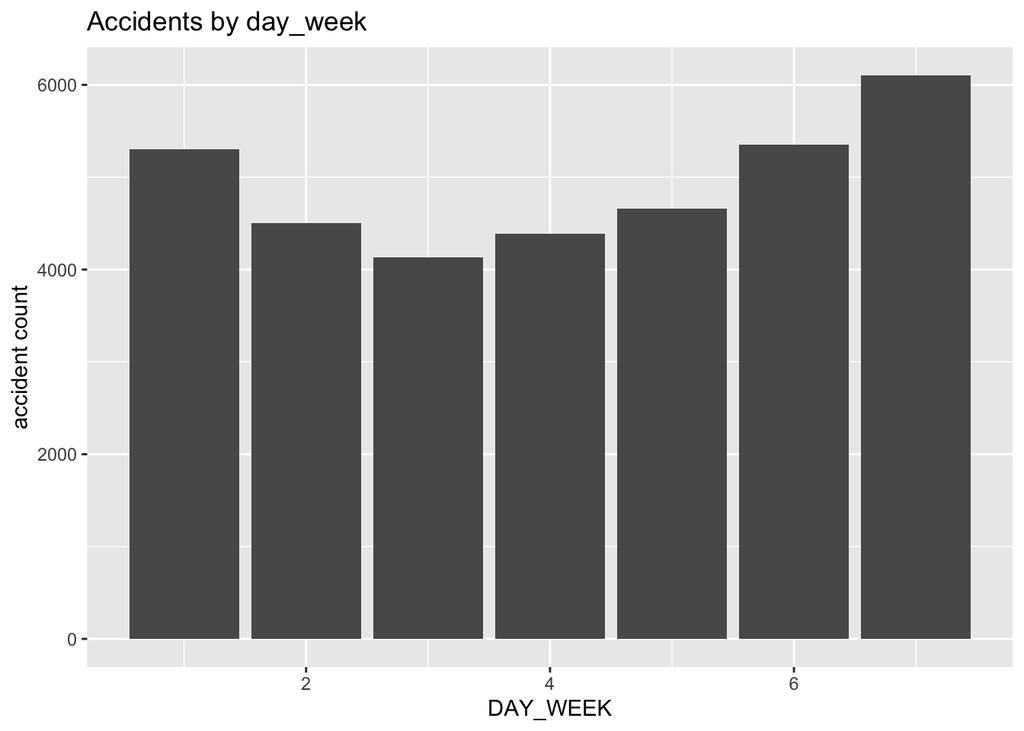

```r
acc %>% ggplot(aes(x=DAY_WEEK)) +
  geom_bar() +
  ggtitle("Accidents by day_week") +
  ylab("accident count")
```

what time of the day do accidents happen (use variable HOUR)?

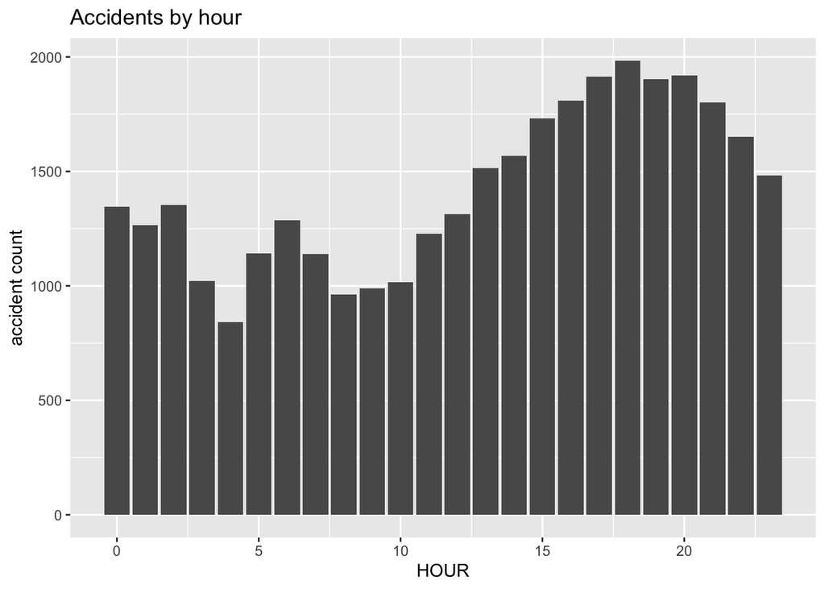

```r
acc.hour = acc %>% filter(HOUR <= 24) %>% group_by(HOUR) %>% tally()
acc.hour %>%
  ggplot(aes(x=HOUR)) +
  geom_bar(aes(weight = n)) +
  ggtitle("Accidents by hour") + ylab("accident count")
```

what is the number of accidents with at least one drunk driver (use variable DRUNK_DR)?

```r
filter(acc, DRUNK_DR > 0) %>% summarize(n=n())
```

```
##      n
## 1 8720
```

#### Slide 5 Answers

The day of the week with the most accidents is the 7th day, and the day with the least is the 3rd day. Unsure which day of the week that specifically is referring to. 1800 (6pm) has the highest count of accidents, while 0400 (4am) has the lowest count of accidents. There are 8,720 accidents that involve atleast one drunk driver.

> **Ngoc Nguyen’s Part 1 answer**<

```r
#overlook the data
str(accidentRaw)
```

```
## 'data.frame':    34439 obs. of  53 variables:
##  $ X         : int  1 2 3 4 5 6 7 8 9 10 ...
##  $ STATE     : int  1 1 1 1 1 1 1 1 1 1 ...
##  $ ST_CASE   : int  10001 10002 10003 10004 10005 10006 10007 10008 10009 10010 ...
##  $ VE_TOTAL  : int  1 1 2 1 1 1 1 1 2 1 ...
##  $ VE_FORMS  : int  1 1 1 1 1 1 1 1 2 1 ...
##  $ PVH_INVL  : int  0 0 1 0 0 0 0 0 0 0 ...
##  $ PEDS      : int  0 0 0 0 0 0 0 0 0 0 ...
##  $ PERNOTMVIT: int  0 0 1 0 0 0 0 0 0 0 ...
##  $ PERMVIT   : int  1 2 1 1 1 1 1 1 4 2 ...
##  $ PERSONS   : int  1 2 2 1 1 1 1 1 4 2 ...
##  $ COUNTY    : int  73 73 73 73 73 109 117 83 103 69 ...
##  $ CITY      : int  1716 1716 0 0 3125 0 530 0 2545 0 ...
##  $ DAY       : int  1 10 1 17 26 1 1 4 4 5 ...
##  $ MONTH     : int  1 1 1 1 1 1 1 1 1 1 ...
```

[output cut: 39 more lines]

- Are there some days of the week where more accidents happen than on others (use variable DAY_WEEK)?

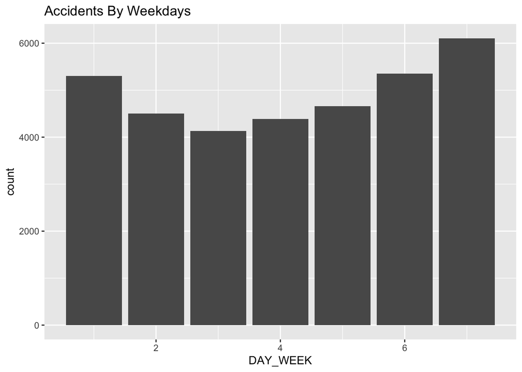

```r
ggplot(accidentRaw, aes(x = DAY_WEEK))+
      geom_bar(aes(fill=DAY_WEEK)) +
      ggtitle("Accidents By Weekdays")
```

- what time of the day do accidents happen (use variable HOUR)?

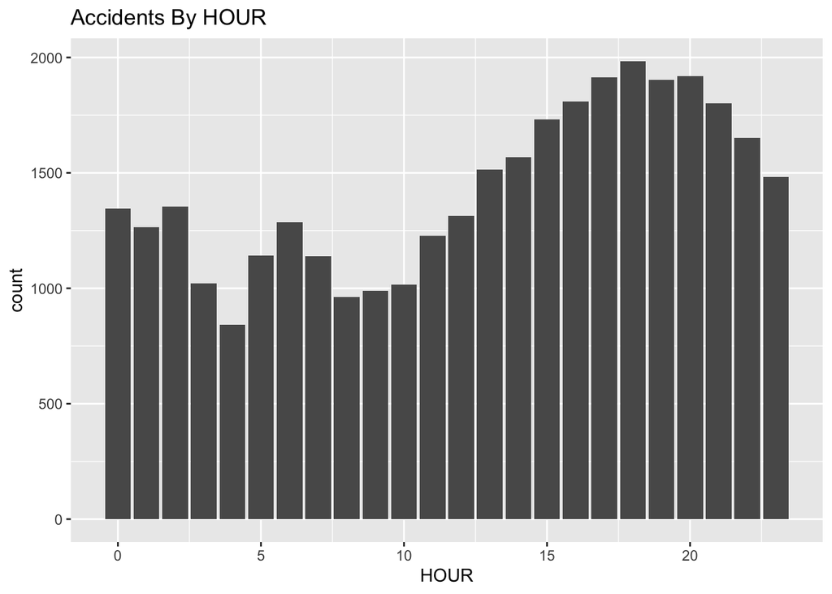

```r
accidentRaw %>%
  filter(HOUR < 24)%>% ggplot(aes(x = HOUR))+ geom_bar(aes(fill=HOUR))+ ggtitle("Accidents By HOUR")
```

what is the number of accidents with at least one drunk driver (use variable DRUNK_DR)?

```r
filter(accidentRaw, DRUNK_DR > 0)%>% summarize(n=n())
```

```
##      n
## 1 8720
```